# Agentic Code Review and Validation

An Introduction to Agentic Coding Assistants

Janick Weberpals, RPh, PhD

AI for Clinical Intelligence and Evidence, AstraZeneca

August 31, 2026

## Disclosures

**Disclosure**

- JW is an employee of the Enterprise AI organization within AstraZeneca and own shares in AstraZeneca.
- JW does not have any financial or personal relationships with Anthropic, Microsoft, or OpenAI, that could influence the content of this presentation.
- Some content in this presentation was generated using Claude Sonnet 5.

# Code Review - The Why?

## Code Review - The Why?<sup>1</sup>

- **Pharmacoepidemiology** is a quantitative discipline which combines knowledge about data, study design, and statistical methods
- **Core competency**: Implementation of a study (data wrangling, statistical analysis) through analytic programming and reproducible code
- **Limited formal training** in programming, version control, and software development best practices
- **Error Prevention**: Coding bugs are inevitable and code review acts as a “safety net”
- **Risk Mitigation**: Encourages the use of validated modular code, which reduces the volume of new, unverified programming for each study
- **Higher Impact**: Release of high-quality, validated code can increase the impact of your research, as others can build upon your work and reproduce your results
- **Operational Transparency & Audit Trail**: Document decisions and have a complete audit trail of all changes, which increases traceability and transparency

[figure not shown]

Figure 1: Systematic code review serves as a critical safeguard against human error in data analysis, enhancing research quality and transparency while fostering a collective culture of reproducibility within the scientific community<sup>1</sup>.

## Consequences of Poor Code Quality

| Severity | Consequence |
| --- | --- |
| 🟡 **Best case** | Inability to re-run the code *(by peers, collaborators, or your future self)* |
| 📊 | Implemented analytics do not reflect the intended study design and analysis plan |
| ⚠️ | Misspecification errors through incorrect coding of exposures, covariates, or outcomes |
| 🔐 | Security vulnerabilities through hardcoding of credentials, API keys, and secrets |
| 🔴 **Worst case** | Invalid results and conclusions, retractions, loss of trust in the scientific community, and potential harm on patients |

## Code Review and Validation

*The Peer Review for Code and Best Practices*

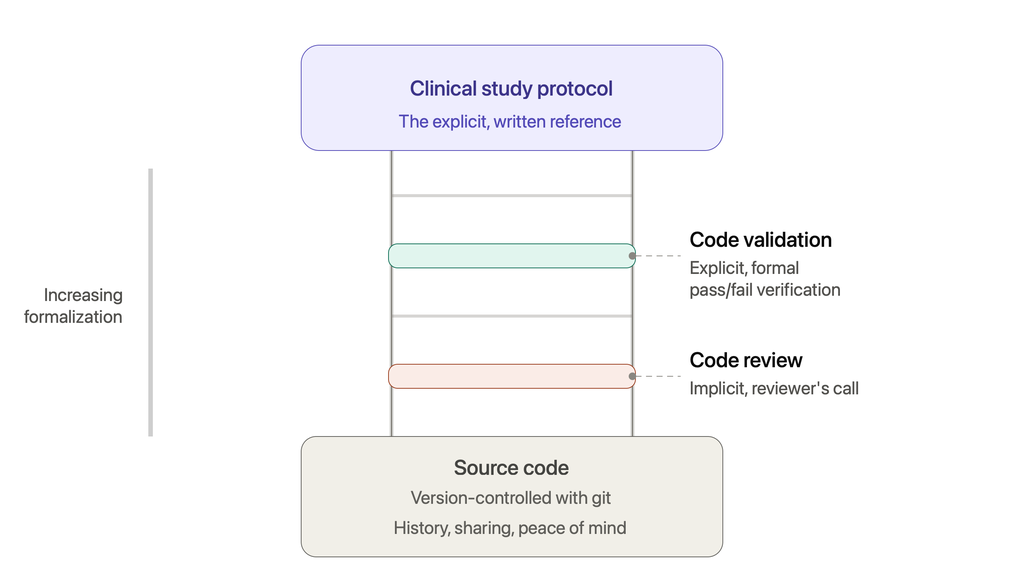

Figure 3: Code review and validation adoption ladder with increasing formalization, from version-controlled source code up to the pre-specified clinical study protocol.

# Code Review - The How?

## Code Review - Pull Request Workflow

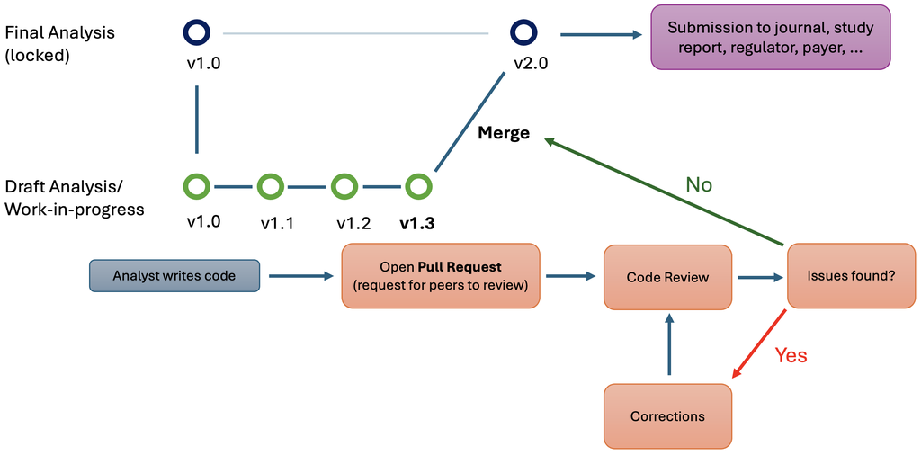

Figure 4: Flowchart of a typical code review workflow as part of a GitHub pull request.

## Code Review - GitHub Demo

[video not shown]

## Code Validation and Unit-Testing

- Unit-tests are a powerful tool for automating the validation of code correctness and protocol adherence (e.g., using `testthat` in R)
- Unit-testing can automate and formalize validation in any applied analytical study and covered **units** are quantifiable

**Structural accuracy** — does the model output make sense?

```
test_that("ATO weights are strictly positive", {
  expect_true(all(W$weights > 0))
})
```

ATO weights equal `ps` (controls) or `1 − ps` (treated). Since `ps ∈ (0, 1)`, a weight ≤ 0 signals a wrong `estimand` or a degenerate propensity score.

**Protocol adherence** — does the code match the pre-specified design?

“*The study window spans from a 365-day washout period before index date (time 0) through up to 365 days of follow-up.*”

```
test_that("all event times ≤ 365 days (CSP §8.3)", {
  events <- cohort[cohort$status == 1, ]
  expect_true(all(events$time <= 365))
})
```

A failure means the censoring logic no longer matches the follow-up window defined in the CSP — catching a silent protocol deviation.

## Manual Code Review Is Time-Consuming

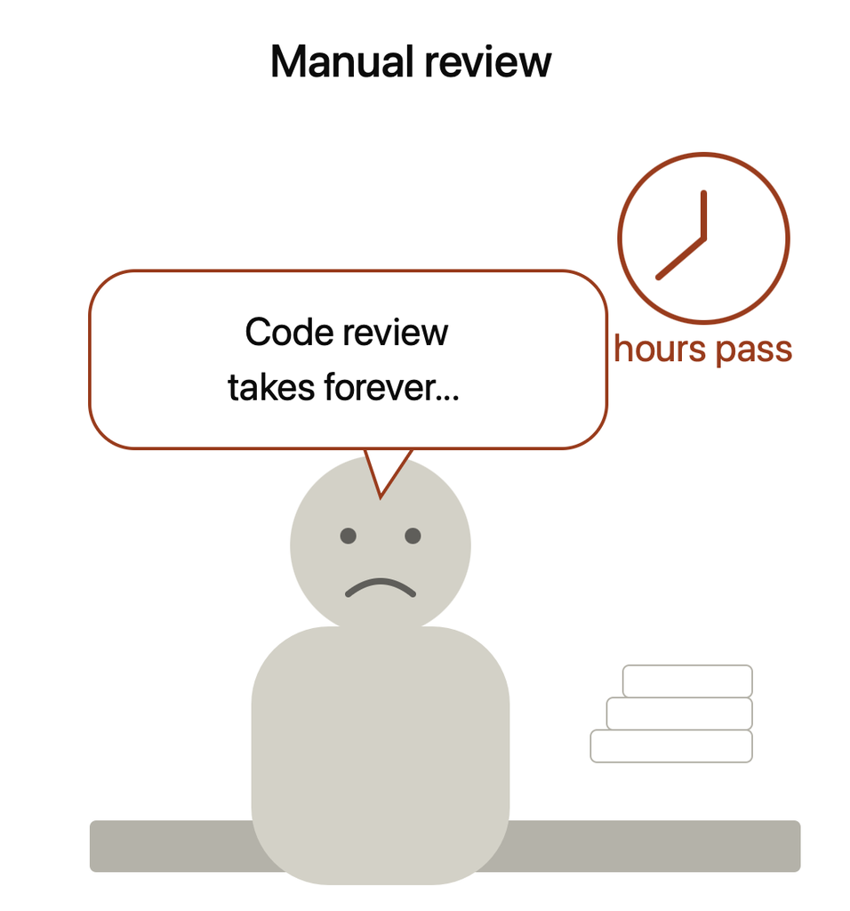

## Coding Agents<sup>3,4</sup>

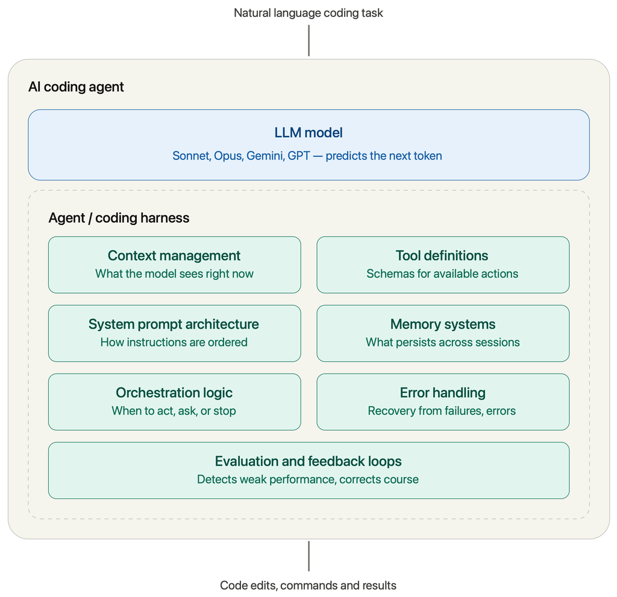

Figure 6: AI coding agents are LLM-based software programs that autonomously perform coding tasks through natural language interactions.

## Context: Repository Structure as Agent Memory

**🤖 Coding Agents Are Context Hungry**

The richer the context, the more targeted and accurate the agentic code review

- 📄 **Protocol & analysis plan** — defines the *intended* study design the code should implement
- 💻 **Analysis scripts** — the code to be reviewed, in logical order
- 📦 **Dependencies & environment** — ensures the agent understands the software stack
- 📚 **References & documentation** — provides scientific and methodological context
- 🗂️ **Data dictionaries** — clarifies variable names, codings, and units
- 🔌 **External Information** — additional external context such as software packages used or common data model concepts (e.g., via MCP servers)

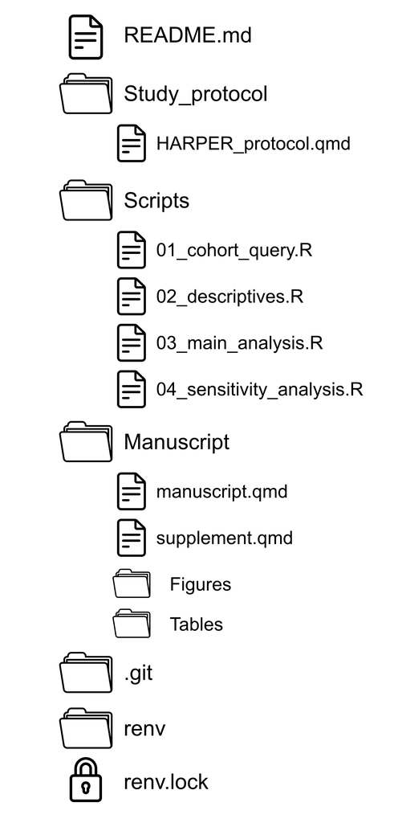

Figure 7: An organized repository structure provides rich context about the intended study & analysis.

## Claude Code - an overview

- Agentic coding tool that reads your codebase, edits files, runs commands, and integrates with your development tools
- Available in in terminal (command line), IDE, desktop app, and browser
- Supports structural (native) and contextual (customizable) **slash commands** **skills**, including code review workflows
- Context customizable to a specific user (`~/.claude`), project, and task (`~/project/.claude`) using a dedicated `.claude` directory in the repository
- [Generic Code Review plugin](https://github.com/anthropics/claude-code/blob/main/plugins/code-review/README.md) that can be invoked via `/code-review` slash command
- No free version, subscription-based or token-based pricing

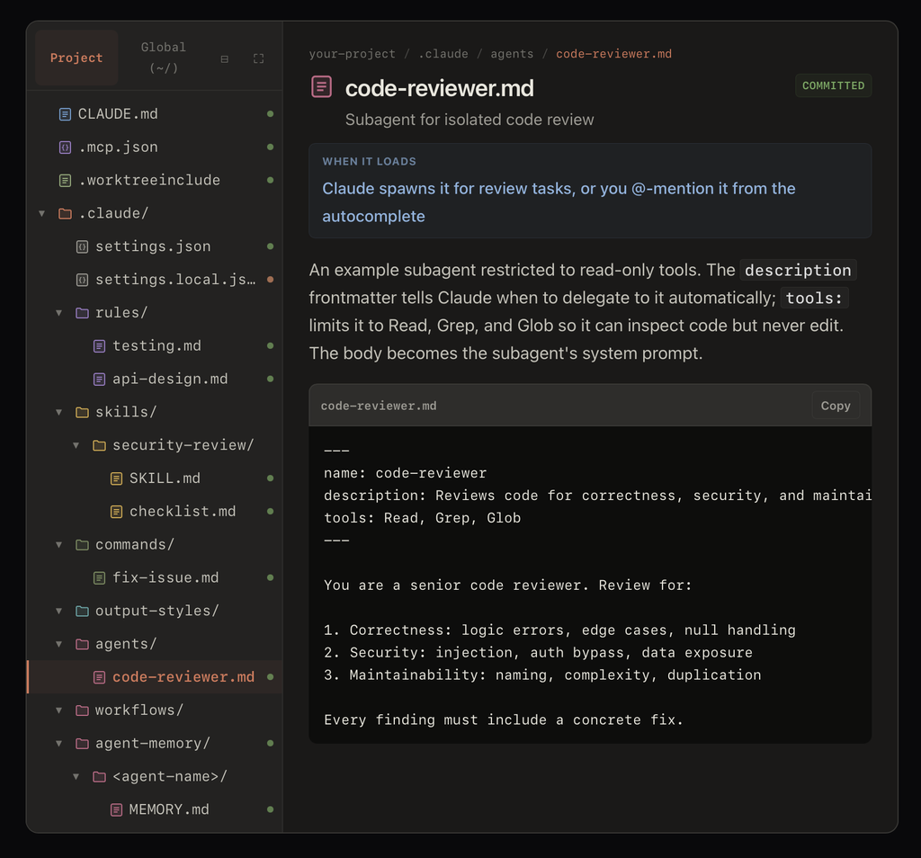

Figure 8: Claude’s abilities are customizable. [Learn more](https://code.claude.com/docs/en/claude-directory#ce-agent-reviewer).

## Anatomy of `/code-reviewer` agent

```markdown
---
name: code-reviewer
description: Reviews code changes for bugs, security issues, performance problems, and style.
tools: Read, Grep, Glob, Bash
model: sonnet
---

You are a senior code reviewer with deep expertise in code quality, security, and software design applied to pharmacoepidemiological studies.

When invoked:

## Determine Scope
- [ ] If the user specified a file, commit, branch, or PR, focus there.
- [ ] If no scope is given, run `git diff HEAD` to review uncommitted/staged changes. If that's empty, fall back to `git diff HEAD~1` (the most recent commit).

## Understand Context
- [ ] Read the changed files in full (not just the diff) to understand the surrounding context naming conventions, existing patterns, related tests.

## Review Checklist

Review for:

### Correctness
- [ ] Any logic errors
- [ ] Edge cases
- [ ] Null handling

### Security Review
- [ ] No hardcoded secrets, paths, access tokens, or credentials
- [ ] Injection
- [ ] Auth bypass
- [ ] Data exposure

### Maintainability
- [ ] Naming conventions
- [ ] Complexity (functions doing too much)
- [ ] Duplication (including .qmd chunk duplicates)
- [ ] Consistency with existing patterns
- [ ] README.md updated

### Validation
- [ ] if @sap.qmd or @csp.qmd is available or the user specified a protocol file, cross-check for consistency with clinical study protocol
- [ ] if testthat/ is available, run unit tests via testthat

### Code Quality Review
- [ ] Conventional commit messages
- [ ] PR description explains what and why
- [ ] Tests cover new functionality
- [ ] Documentation updated
- [ ] Dependencies are up to date and secure

Every finding must include a brief explanation and a concrete fix. Do not execute code.

## Output format:
- [ ] Group findings by severity: **Critical**, **Warning**, **Suggestion**
- [ ] For each finding: file path, line number(s), a short explanation, and a concrete fix or example
- [ ] End with a one-line verdict, e.g. "Ready to merge" or "Needs changes before merge"

Be specific, cite exact lines, and suggest fixes rather than just naming problems. You are strictly read-only — never edit, write, or modify files. Git and grep commands are permitted.
```

## Claude Code - Demo

[video not shown]

## PROS of Coding Agents

🌱

AI-ready foundations

Enforces best practices on version control, history, and documentation

✅

Front-loaded review

Flags issues before a human ever looks

📈

Long-term ROI

Upfront investment pays off in speed and quality over time

🧪

Tailored to your lab

Custom agents configured for your team’s context

🧭

Faster onboarding

Immediate, consistent feedback for junior researchers learning new tools and team conventions

## CONS of Coding Agents

💲

Costs ($$$)

- Coding agents add another layer of cost (subscriptions, token-based billing)
- Local, open-source coding agents are an alternative, but don’t yet match the same performance
- Educational licenses are available for academic institutions

🔒

Privacy vs. context

- Data governance and residency: where code and data are processed and stored (cloud vs. on-prem, data use agreements)
- Increasing agent autonomy requires stronger guardrails
- Risk of exposing PII or other sensitive data if unchecked

🔗

Dependence

- Cutting-edge coding agents come from a small number of hyperscalers
- Access can be subject to export controls (e.g., Claude Fable/Mythos, June 2026)

🔄

Reproducibility of the review itself

- Agent behavior can shift across reviews, model versions, or updates
- May be a minor issue since human reviews aren’t 100% reproducible either (inter-reviewer agreement)

## Famous Last Words

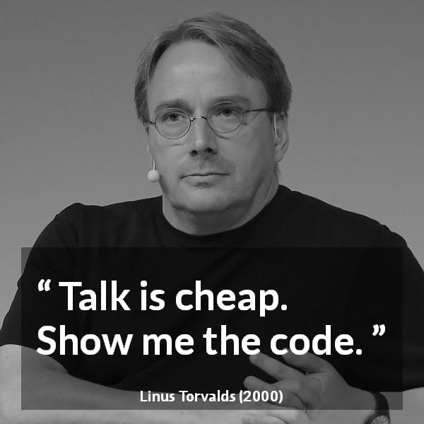

Figure 9: Linus Torvalds, developer of `git` and the `Linux kernel`.

## Acknowledgements

**Thank You**

Many thanks to the following colleagues for their input and feedback on this presentation:

- **AstraZeneca (Enterprise AI)**: Alex Grigorenko, Leonidas Souliotis, Yannis Darhi, Muhammad Ekram, Sam Hillman, Sajan Khosla
- **Transparency and Reproducibility A-team**: Anton Pottegard, Shirley V. Wang, Dani Prieto-Alhambra, Mina Tadrous

## Bonus: Interacting with code using natural language<sup>5</sup>

[video not shown]

## Key Takeaways & Next Steps

🧠 REMEMBER

🛡️

Review is a safety net, not a formality

Bugs are inevitable — undetected ones can invalidate results and harm patients

🗂️

Your repo *is* the agent’s memory

A well-organized project repository, including protocol, analysis scripts, dependencies, and documentation makes agentic **AND** human review sharper and more targeted

🤝

Augment, don’t replace

Agentic review and validation speeds up the first pass — human review still required & you still own the judgment call

FROM INSIGHT TO ACTION

✅ DO THIS BACK AT THE OFFICE

⚙️

Check your current project repository

Would another human understand the structure and included analytic code?

🔍

Ask a colleague to provide a code review

If you haven’t already, ask a colleague to provide a code review and test out a pull request workflow on GitHub

🧪

Create your own `/code-reviewer.md` agent file

Think about what checks are important and how you would instruct a coding agent to review your project (+/- use an actual coding assistant to perform the code review)

## Key Links and References

**Version control (git, GitHub)**

- [ICPE 2025 pre-conference course materials](https://janickweberpals.github.io/icpe-git-2025/)
- Weberpals J and Wang SV. The FAIRification of research in real-world evidence: A practical introduction to reproducible analytic workflows using Git and R. Pharmacoepidemiol Drug Saf. 2024 Jan;33(1):e5740. [doi: 10.1002/pds.5740.](https://onlinelibrary.wiley.com/doi/10.1002/pds.5740)<sup>6</sup>
- Tazare J, Wang SV, Gini R, et al. Sharing Is Caring? International Society for Pharmacoepidemiology Review and Recommendations for Sharing Programming Code. Pharmacoepidemiol Drug Saf. 2024 Sep;33(9):e5856. [doi: 10.1002/pds.5856.](https://onlinelibrary.wiley.com/doi/10.1002/pds.5856)<sup>7</sup>
- Schultze A, Tazare J. The role of programming code sharing in improving the transparency of medical research. BMJ. 2023 Oct 17;383:2402. [doi: 10.1136/bmj.p2402](https://www.bmj.com/content/383/bmj.p2402.long).<sup>8</sup>
- Pharmacoepidemiology and Drug Safety Special Issue on Pharmacoepidemiology Research Reproducibility

**Code review and coding agents**

- Vable AM, Diehl SF, Glymour MM. Code Review as a Simple Trick to Enhance Reproducibility, Accelerate Learning, and Improve the Quality of Your Team’s Research. Am J Epidemiol. 2021 Oct 1;190(10):2172-2177. [doi: 10.1093/aje/kwab092.](https://academic.oup.com/aje/article-abstract/190/10/2172/6218064?redirectedFrom=fulltext&login=false)
- Claude Code - [Code Review Skill documentation](https://code.claude.com/docs/en/code-review#review-a-diff-locally)
- [Introduction to GitHub Copilot and Coding Assistants](https://janickweberpals.github.io/icpe-git-2025/04_copilot.html), ICPE 2025 pre-conference materials

## References

1.

Vable AM, Diehl SF, Glymour MM. Code review as a simple trick to enhance reproducibility, accelerate learning, and improve the quality of your team’s research. *American Journal of Epidemiology* 2021; **190**: 2172–2177.

2.

Gander JC, Zhang X, Ross K, *et al.* Notice of retraction and replacement. Gander et al. Association between dialysis facility ownership and access to kidney transplantation. JAMA. 2019; 322 (10): 957-973. *JAMA* 2020; **323**: 1509–1510.

3.

Raschka S. Components of a coding agent. *Ahead of AI* 2026. Available at: https://magazine.sebastianraschka.com/p/components-of-a-coding-agent.

4.

MindStudio Team. Agent harness engineering: Why your wrapper matters more than the model. *MindStudio Blog* 2026. Available at: https://www.mindstudio.ai/blog/agent-harness-engineering-wrapper-matters-more-than-model.

5.

Abdelaziz AI, Hanson KA, Gaber CE, Lee TA. Optimizing large real-world data analysis with parquet files in r: A step-by-step tutorial. *Pharmacoepidemiology and Drug Safety* 2024; **33**: e5728.

6.

Weberpals J, Wang SV. The FAIRification of research in real-world evidence: A practical introduction to reproducible analytic workflows using git and r. *Pharmacoepidemiology and Drug Safety* 2024; **33**: e5740. doi:10.1002/pds.5740.

7.

Tazare J, Wang S, Gini R, *et al.* Sharing is caring? International society of pharmacoepidemiology review and recommendations for sharing of programming code. 2024. doi:10.22541/au.171032639.91688014/v1.

8.

Schultze A, Tazare J. The role of programming code sharing in improving the transparency of medical research. *BMJ* 2023; **383**: 2402. doi:10.1136/bmj.p2402.